# Spatial Correction of Field Trial Data Using GAMM

Usage guide for `SpatialCorrectionGAMM.R`

06 March 2026

## Overview

`SpatialCorrectionGAMM.R` provides a complete pipeline for removing environmental spatial gradients from unreplicated or partially replicated glasshouse and field trial data. It uses penalised regression splines (via **mgcv**) combined with genotype and positional random effects (via **nlme**) fitted under REML, producing spatially corrected plot-level phenotypes and genotype-level Best Linear Unbiased Predictions (BLUPs).

**Experimental design this pipeline is designed for:**

- Multi-bench or multi-environment unreplicated trial: each genotype appears **once per bench**, randomly assigned to a plot position
- Bench layout: a regular row × column grid
- Observed phenotype = true genotype value + spatial gradient + random noise

**Outputs:**

| File | Contents |
| --- | --- |
| `GAMM_plots.pdf` | 6-panel diagnostic page per trait × bench |
| `GAMM_fitted_values.csv` | Plot-level: observed, fitted, residual, and corrected values |
| `GAMM_BLUPs.csv` | Genotype-level BLUPs per bench, plus cross-bench mean rows |
| `Outliers_GAMM_report.txt` | Outlier log with positions and residual values |

## Statistical model

### Data-generating process

For bench $b$, each plot $(i, j)$ carrying genotype $k$ contributes an observed phenotype:

$$y_{ijk} = \mu + g_k + f(r_i,\, c_j) +
\rho_i + \kappa_j + \varepsilon_{ijk}$$

where:

| Term | Meaning |
| --- | --- |
| $\mu$ | Grand mean (fixed intercept) |
| $g_k \sim N(0,\,\sigma_g^2)$ | Genotype random effect |
| $f(r_i, c_j)$ | Fixed spatial surface smooth — captures large-scale environmental gradient |
| $\rho_i \sim N(0,\,\sigma_\rho^2)$ | Row random effect — residual row-level variation not captured by the smooth |
| $\kappa_j \sim N(0,\,\sigma_\kappa^2)$ | Column random effect |
| $\varepsilon_{ijk} \sim N(0,\,\sigma^2)$ | Residual plot-level error |

All random terms are independent. REML estimation via `gamm()` simultaneously estimates the spatial smooth and the variance components $\sigma_g^2,\,\sigma_\rho^2,\,\sigma_\kappa^2,\,\sigma^2$.

### The spatial smooth $f(r, c)$

The spatial surface is represented as a **tensor product P-spline**:

$$f(r, c) = \sum_{k_1=1}^{K_r}
\sum_{k_2=1}^{K_c}
\theta_{k_1 k_2}\; B_{k_1}(r) \otimes
B_{k_2}(c)$$

where $B_{k_1}(r)$ and $B_{k_2}(c)$ are B-spline basis functions. Smoothness is enforced by discrete second-difference penalties on the rows and columns of the coefficient matrix $\Theta$. The penalty strength is selected automatically by REML.

The number of basis functions ($K_r \times K_c$) is set by `auto_k_dims()`:

$$K_r = \max(3,\; \lfloor n_\text{rows}/2
\rfloor), \quad
K_c = \max(3,\; \lfloor n_\text{cols}/2 \rfloor)$$

This is conservative — enough knots to represent realistic gradients while avoiding overfitting. For complex or non-monotone surfaces you can supply `k_dims` manually.

**Why tensor products rather than isotropic smooths?** Row and column spacing are typically different, and gradients often differ in magnitude along rows vs columns (e.g. a strong temperature gradient along the bench length but little variation across its width). Tensor product splines apply separate penalties in each direction, so they are more appropriate than isotropic `s(row, col, bs="tp")` for field-trial layouts.

### Relationship to SpATS / SAP

The model is closely related to the SpATS approach of Rodriguez-Alvarez et al. (2018) and the P-spline spatial models reviewed by Piepho et al. (2015). The key differences here are:

- `gamm()` leverages the **nlme** mixed-model engine for REML, giving genuine shrinkage BLUPs from `ranef()` rather than approximate predictions
- Row and column random effects provide an additional layer of local correction on top of the smooth spatial surface

### Spatial correction and BLUPs

**Corrected plot phenotype.** The mean-centred spatial trend and positional random effects are subtracted from the observed value:

$$y^{*}_{ijk} = y_{ijk} -
\bigl[\hat{f}(r_i,c_j) - \overline{\hat{f}}\bigr]
- \hat{\rho}_i - \hat{\kappa}_j$$

This leaves the grand mean, genotype BLUP, and residual error intact, producing corrected values on the original phenotype scale.

**Genotype BLUPs.** The adjusted genotype mean is:

$$\hat{\mu}_k = \hat{\mu} +
\hat{g}_k$$

where $\hat{g}_k$ is the BLUP from `ranef(model$lme)[[gt_col]]`.

**Reliability** (shrinkage coefficient):

$$h^2_r = \frac{\sigma_g^2}{\sigma_g^2 +
\sigma^2 / n_\text{rep}}$$

A reliability near 1 means the BLUP is close to the raw mean; near 0 means heavy shrinkage toward the grand mean due to low genotypic signal.

## Function reference

### Helper functions

#### `auto_k_dims(mydfr, rn, cn)`

Automatically selects the number of tensor-product spline basis functions for a given bench.

| Argument | Description |
| --- | --- |
| `mydfr` | Data frame for a single bench |
| `rn` | Name of the row column |
| `cn` | Name of the column column |

Returns `c(k_row, k_col)`: integer vector used as the `k` argument to `te()`.

#### `fit_gamm_spatial(mydfr, pheno, gt, rn, cn, k_dims)`

Fits the GAMM model for one bench × one trait. Attaches the prepared data frame as an attribute for downstream use.

| Argument | Description |
| --- | --- |
| `mydfr` | Single-bench data frame |
| `pheno` | Name of the response column |
| `gt` | Name of the genotype column |
| `rn` | Name of the row column |
| `cn` | Name of the column column |
| `k_dims` | Integer vector `c(k_row, k_col)` from `auto_k_dims()` |

Returns a `gamm()` object with components `$gam` and `$lme`.

#### `detect_outliers_residuals(model, mydfr, rn, cn, method, k)`

Flags outliers from the model’s level-1 (within-group) conditional residuals. These residuals have the genotype and smooth contributions removed, so only genuine measurement errors or data entry mistakes should be flagged.

| Argument | Default | Description |
| --- | --- | --- |
| `model` | — | `gamm()` object |
| `mydfr` | — | Data frame used to fit the model |
| `rn` | — | Row column name |
| `cn` | — | Column column name |
| `method` | `"IQR"` | `"IQR"`: flag beyond $Q_1 - k \cdot \text{IQR}$ or $Q_3 + k \cdot \text{IQR}$; `"SD"`: flag beyond mean $\pm\, k \cdot \text{SD}$ |
| `k` | `3` | Threshold multiplier (3 is conservative) |

Returns a logical vector (length = rows in `mydfr`); `TRUE` = outlier.

#### `extract_blups_gamm(model, mydfr, gt, n_rep)`

Extracts genotype BLUPs, standard error, and reliability from a fitted model.

| Argument | Default | Description |
| --- | --- | --- |
| `model` | — | `gamm()` object |
| `mydfr` | — | Data frame (must have `gt` column as a factor) |
| `gt` | — | Genotype column name |
| `n_rep` | `1` | Replicates per genotype per bench (1 for unreplicated designs) |

Returns a data frame: `Genotype`, `predicted`, `StdErr`, `reliability`.

#### `compute_variogram(resids, rows, cols, n_bins, max_pairs)`

Computes an empirical variogram of the model residuals. Used diagnostically: a flat variogram after correction confirms no remaining spatial autocorrelation in the residuals.

| Argument | Default | Description |
| --- | --- | --- |
| `resids` | — | Numeric residual vector |
| `rows` | — | Row positions |
| `cols` | — | Column positions |
| `n_bins` | `15` | Number of distance bins |
| `max_pairs` | `5000` | Maximum random pairs evaluated (for speed) |

Returns a data frame: `dist_bin_mid`, `semivariance`, `n_pairs`.

#### `plot_spatial_diagnostics(model, mydfr, blups, pheno, bench_label, rn, cn, gt)`

Builds a six-panel **patchwork** diagnostic page for one trait × one bench.

[output not shown]

Returns a patchwork ggplot object.

### Main pipeline function

#### `run_spatial_gamm(mydfr, pheno, gt, rn, cn, bench_label, pmain, outlier_method, outlier_k)`

Full pipeline for one bench × one trait:

1. Auto-select `k_dims`
2. Fit an initial GAMM
3. Flag outliers on conditional residuals; replace with `NA`
4. Re-fit GAMM on cleaned data
5. Extract BLUPs and per-plot corrected values
6. Print a 6-panel diagnostic page to the active graphics device

| Argument | Default | Description |
| --- | --- | --- |
| `mydfr` | — | Single-bench data frame |
| `pheno` | — | Response column name |
| `gt` | — | Genotype column name |
| `rn` | — | Row column name |
| `cn` | — | Column column name |
| `bench_label` | — | String identifier for this bench (used in titles and output) |
| `pmain` | — | Plot title prefix |
| `outlier_method` | `"IQR"` | Outlier detection method (`"IQR"` or `"SD"`) |
| `outlier_k` | `3` | Multiplier for outlier threshold |

Returns `list(dfrF, dfrP)`:

- `dfrF`: plot-level data frame with `*_Observed`, `*_Fitted`, `*_Residual`, `*_Corrected` columns
- `dfrP`: BLUP data frame with `*_StdErr` and `*_Reliability` columns

#### `plot_smooth_heatmap(model, mydfr, rn, cn, bench_label, pheno_label)`

Standalone plot of the fitted spatial surface on the **actual plot grid** (one tile per plot, not interpolated). Uses a diverging blue–white–red colour scale centred at zero:

- **Blue tiles** — plots suppressed by the environment; their observed value was lower than their true genotype effect; the correction adds to the observed value
- **Red tiles** — plots elevated by the environment; the correction subtracts from the observed value

| Argument | Default | Description |
| --- | --- | --- |
| `model` | — | `gamm()` object (per-bench or pooled) |
| `mydfr` | — | Data frame used to fit the model |
| `rn` | — | Row column name |
| `cn` | — | Column column name |
| `bench_label` | `""` | Label shown in the plot title |
| `pheno_label` | `"Spatial\ntrend"` | Fill legend label |

Returns a `ggplot` object.

Note: this function is called automatically inside `run_spatial_gamm()` and `run_spatial_gamm_pooled()` after the 6-panel diagnostics.

#### `fit_gamm_pooled(dfr, pheno, gt, rn, cn, bench_col, k_dims)`

Fits one GAMM for all benches simultaneously with a **shared** spatial smooth. `Bench` is included as a fixed effect to absorb between-bench mean differences. Row and column random effects are bench-specific (named `Bench_rN` and `Bench_cN`) to prevent row 1 in bench A from being treated as the same group as row 1 in bench B.

Use this when you have good reason to believe the spatial gradient has the same shape on every bench (e.g. identical bench construction, same orientation relative to heating/lighting). When patterns differ, prefer `fit_gamm_spatial()` called separately per bench.

#### `extract_blups_gamm_pooled(model, dfr, gt, bench_col)`

Extracts genotype BLUPs from a pooled model. The grand mean is computed as the intercept plus the **average of all bench fixed effects**, so that the reported BLUP is not anchored to any single reference bench.

### Controlling which benches are processed

Both the script and the Rmd tutorial support partial bench processing via `bench_filter`. This is useful for quick testing or when some benches have data quality issues.

```r
bench_filter <- NULL          # (default) process all benches
bench_filter <- c("Bench1")   # process only Bench1
bench_filter <- c("Bench1", "Bench3")  # process a subset
```

When `bench_col = NULL` (no bench structure in the data), `bench_filter` has no effect and all data are processed as a single field.

### Choosing between separate and shared smoothers

| Setting | When to use |
| --- | --- |
| `separate_smoothers = TRUE` (default) | Different benches may have different spatial gradients. Each bench gets its own `te(Row, Col)` surface estimated independently. No assumption about pattern similarity across benches. |
| `separate_smoothers = FALSE` | You have reason to believe all benches share the same spatial gradient (same equipment, same orientation). Pooling borrows strength across benches and produces a single cross-bench BLUP directly. |

### Using the script directly

Edit the **CONFIG** section near the bottom of `SpatialCorrectionGAMM.R`:

```r
fn          <- "path/to/your_data.csv"   # input file
fnpdf       <- "GAMM_plots.pdf"
report_file <- "Outliers_GAMM_report.txt"
fnFitted    <- "GAMM_fitted_values.csv"
fnPredicted <- "GAMM_BLUPs.csv"

gt_col    <- "Genotype"    # column name for genotypes
rn_col    <- "Row"         # column name for row positions
cn_col    <- "Column"      # column name for column positions
bench_col <- "Bench"       # set to NULL for a single field with no bench column
trFc      <- 5             # column index of the FIRST trait (traits run from here to the end)

outlier_method <- "IQR"    # "IQR" or "SD"
outlier_k      <- 3        # multiplier (3 is conservative)

bench_filter       <- NULL   # NULL = all benches; e.g. c("Bench1","Bench2") to process a subset
separate_smoothers <- TRUE   # TRUE = separate smooth per bench (default); FALSE = shared smooth
```

Then run: `Rscript scripts/SpatialCorrectionGAMM.R`

The CONFIG section is skipped when the script is sourced from R or knitted.

## Tutorial — Example 1: Uniform column gradient

### Scenario

Four glasshouse benches, each containing 150 plots (10 rows × 15 columns). A half-sine temperature gradient runs along the length of each bench (column direction), with identical magnitude and shape on all benches. The spatial effect peaks at ~25 BNI units, comparable in scale to the between-genotype SD (12 units) — a realistic but challenging correction problem.

We will:

1. Simulate the data and visualise the raw spatial patterns
2. Run the spatial GAMM per bench
3. Examine the diagnostic plots
4. Extract BLUPs and compare them to the known true genotype effects

### Setup

```r
source("../scripts/simulate_spatial_data.R")
source("../scripts/SpatialCorrectionGAMM.R")

library(dplyr)
library(tidyr)
library(ggplot2)
library(patchwork)
```

### Simulate data

```r
sim1 <- simulate_field_trial(
  n_bench           = 4,
  n_rows            = 10,
  n_cols            = 15,
  mean_pheno        = 55,
  sd_geno           = 12,
  spatial_type      = 3,          # column gradient
  spatial_intensity = 25,
  spatial_scale     = 1,
  sd_error          = 4,
  pheno_name        = "BNI",
  save_csv          = TRUE,
  output_dir        = "data",
  seed              = 42
)
```

```
## Data written to:          data/BNI_simulation.csv
## True effects written to:  data/BNI_true_effects.csv
```

```r
cat("Plots:     ", nrow(sim1$data), "\n")
```

```
## Plots:      600
```

```r
cat("Genotypes: ", length(unique(sim1$data$Genotype)), "\n")
```

```
## Genotypes:  150
```

```r
cat("Benches:   ", length(unique(sim1$data$Bench)), "\n")
```

```
## Benches:    4
```

```r
head(sim1$data)
```

```
##    Bench Genotype Row Col      BNI
## 1 Bench1     G118   1   1 85.71370
## 2 Bench1     G061   2   1 48.09786
## 3 Bench1     G102   3   1 68.32882
## 4 Bench1     G054   4   1 68.71719
## 5 Bench1     G055   5   1 51.51443
## 6 Bench1     G147   6   1 51.21548
```

### Raw observed heatmaps

```r
plot_all_bench_heatmaps(
  dfr          = sim1$data,
  pheno        = "BNI",
  bench_col    = "Bench",
  shared_scale = TRUE,
  ncol_panels  = 2,
  panel_width  = 7,
  panel_height = 4,
  output_png   = "data/ex1_raw_heatmap.png"
)
```

```
## Heatmap saved to: data/ex1_raw_heatmap.png
```

### True genotype effect distribution

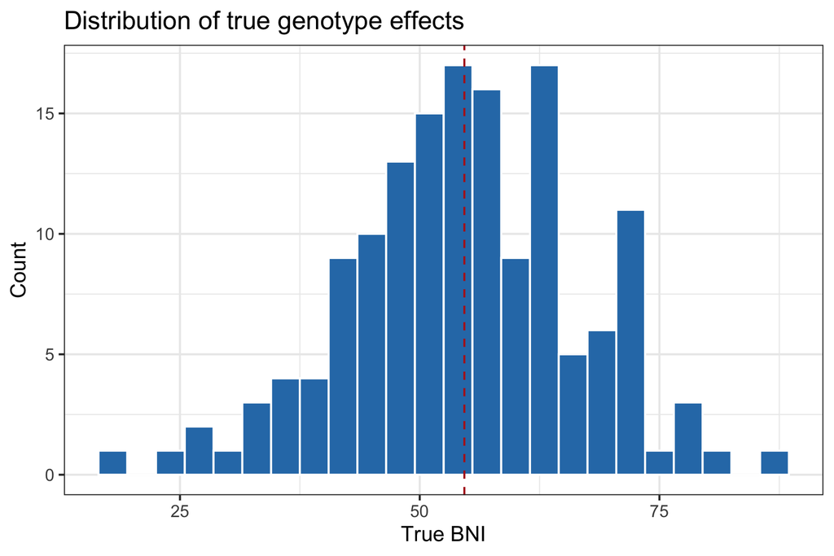

```r
ggplot(sim1$true_effects, aes(x = True_BNI)) +
  geom_histogram(binwidth = 3, fill = "#2c7bb6", colour = "white") +
  geom_vline(xintercept = mean(sim1$true_effects$True_BNI),
             colour = "firebrick", linetype = "dashed") +
  labs(title = "Distribution of true genotype effects",
       x = "True BNI", y = "Count") +
  theme_bw()
```

### Run spatial GAMM — one bench at a time

Each call to `run_spatial_gamm()` fits the full pipeline for one bench and automatically prints a 6-panel diagnostic page. Progress messages are shown below each run.

```r
benches_ex1    <- unique(sim1$data$Bench)
results_ex1    <- list()
fitted_ex1     <- NULL

for (b in benches_ex1) {

  bench_data <- sim1$data[sim1$data$Bench == b, ]

  res <- run_spatial_gamm(
    mydfr          = bench_data,
    pheno          = "BNI",
    gt             = "Genotype",
    rn             = "Row",
    cn             = "Col",
    bench_label    = b,
    pmain          = paste("Ex1", b),
    outlier_method = "IQR",
    outlier_k      = 3
  )

  if (!is.null(res)) {
    results_ex1[[b]] <- res
    fitted_ex1 <- if (is.null(fitted_ex1)) res$dfrF else rbind(fitted_ex1, res$dfrF)
  }
}
```

```
##
## --- Bench: Bench1 | Trait: BNI ---
##   k_dims: 5 x 7
##   Fitting initial GAMM...
##   Detecting outliers (method = IQR , k = 3 )...
##   Outliers detected: 0
##   No outliers found.
## [REPORT] Bench: Bench1 | Trait: BNI
## [REPORT] Method: IQR | k: 3 | Outliers: 0
## [REPORT] ---
##   Fitting final GAMM on cleaned data...
##   Generating diagnostic plots...
```

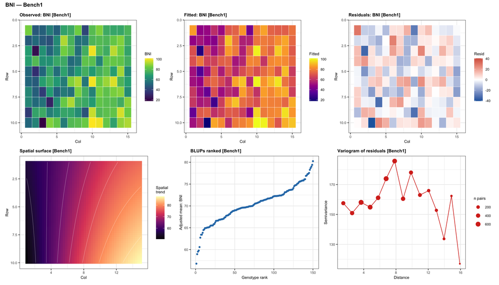

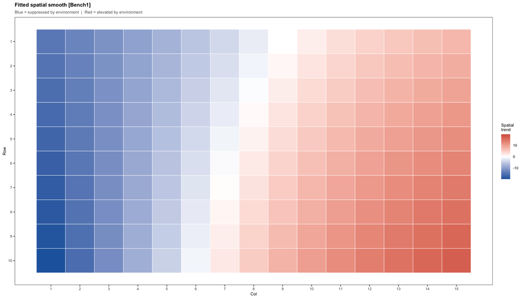

```
##
## --- Bench: Bench2 | Trait: BNI ---
##   k_dims: 5 x 7
##   Fitting initial GAMM...
##   Detecting outliers (method = IQR , k = 3 )...
##   Outliers detected: 0
##   No outliers found.
## [REPORT] Bench: Bench2 | Trait: BNI
## [REPORT] Method: IQR | k: 3 | Outliers: 0
## [REPORT] ---
##   Fitting final GAMM on cleaned data...
##   Generating diagnostic plots...
```

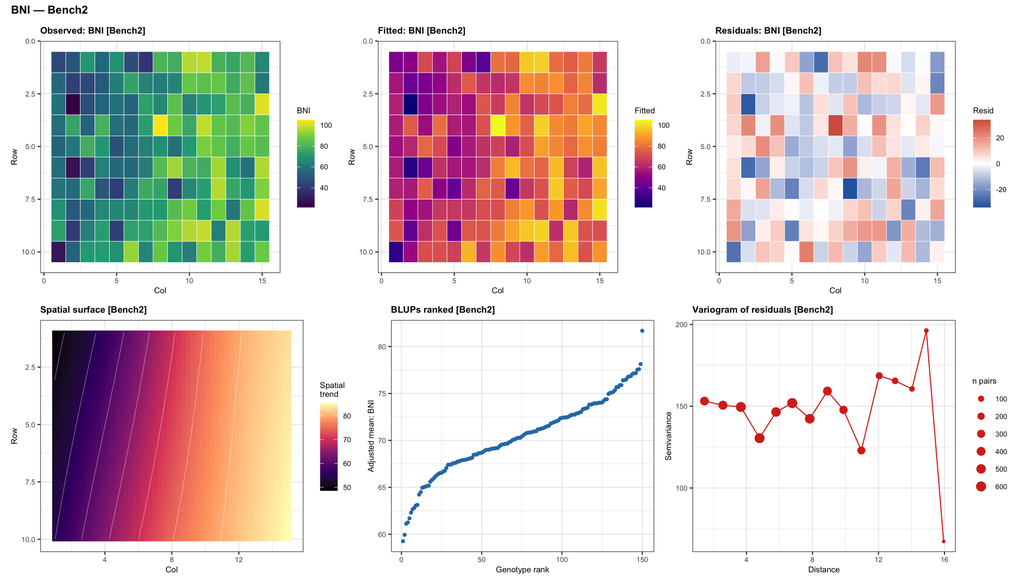

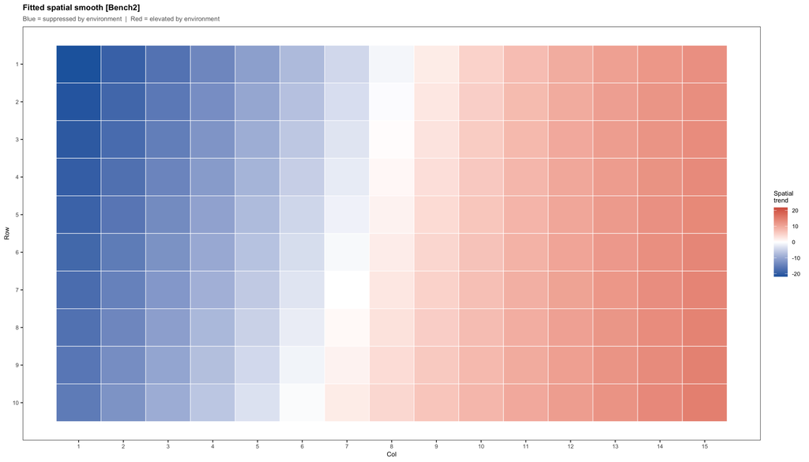

```
##
## --- Bench: Bench3 | Trait: BNI ---
##   k_dims: 5 x 7
##   Fitting initial GAMM...
##   Detecting outliers (method = IQR , k = 3 )...
##   Outliers detected: 0
##   No outliers found.
## [REPORT] Bench: Bench3 | Trait: BNI
## [REPORT] Method: IQR | k: 3 | Outliers: 0
## [REPORT] ---
##   Fitting final GAMM on cleaned data...
##   Generating diagnostic plots...
```

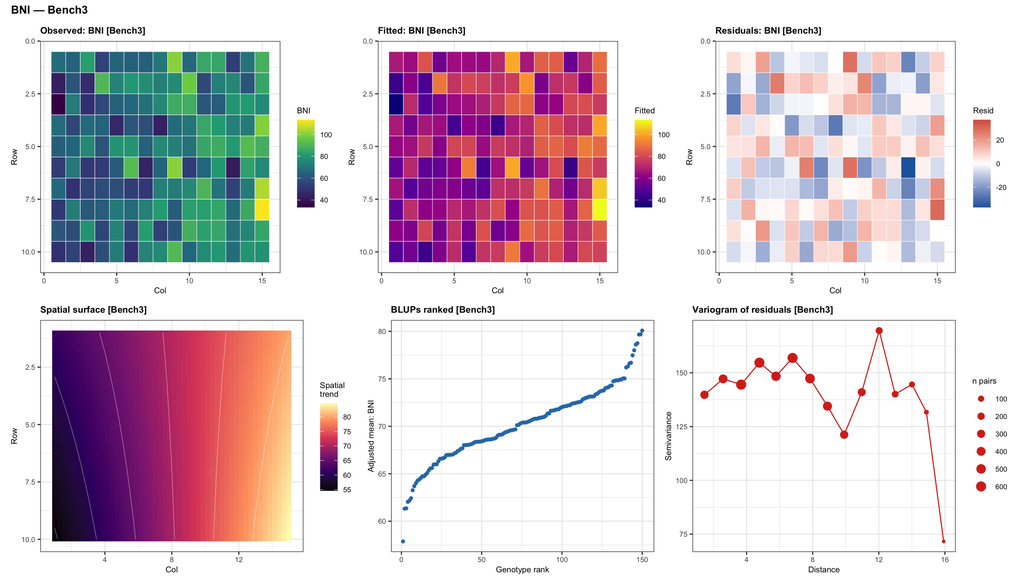

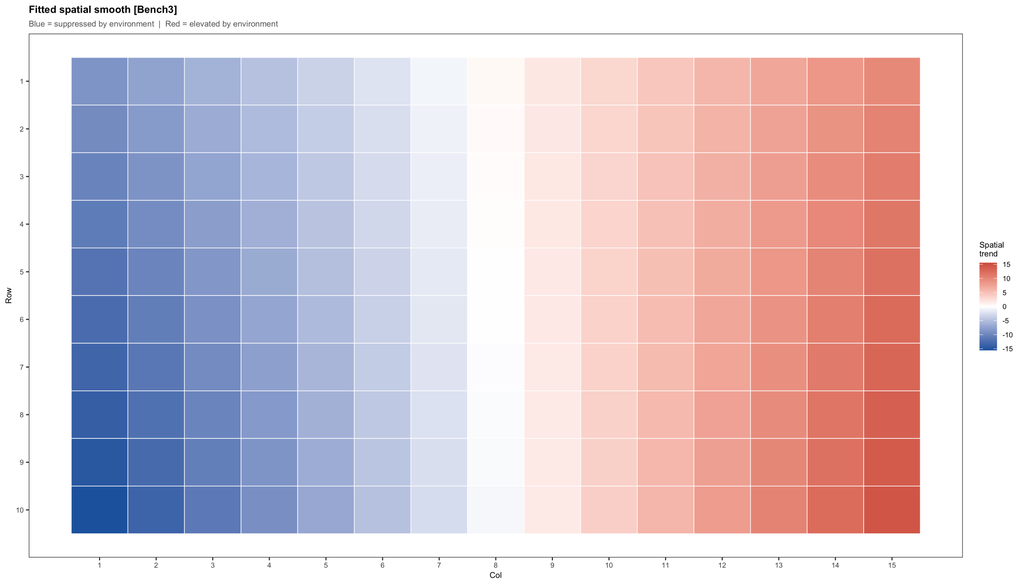

```
##
## --- Bench: Bench4 | Trait: BNI ---
##   k_dims: 5 x 7
##   Fitting initial GAMM...
##   Detecting outliers (method = IQR , k = 3 )...
##   Outliers detected: 0
##   No outliers found.
## [REPORT] Bench: Bench4 | Trait: BNI
## [REPORT] Method: IQR | k: 3 | Outliers: 0
## [REPORT] ---
##   Fitting final GAMM on cleaned data...
##   Generating diagnostic plots...
```

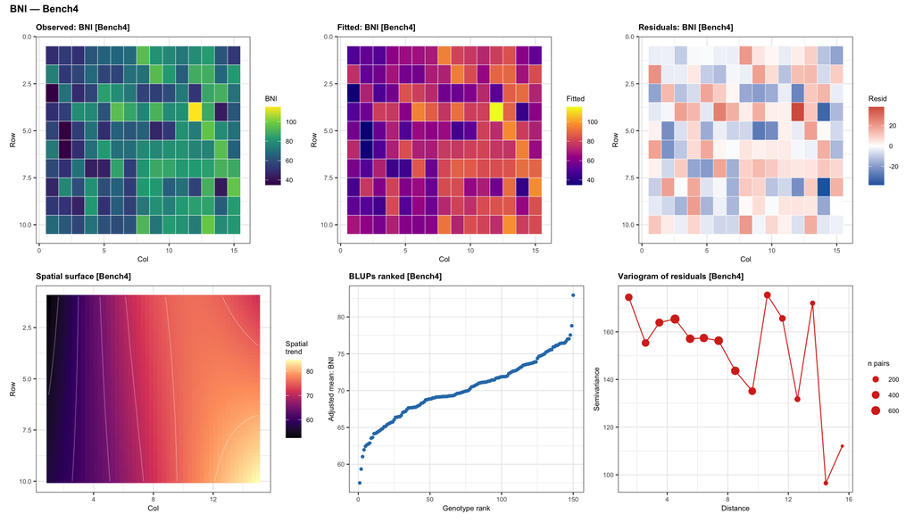

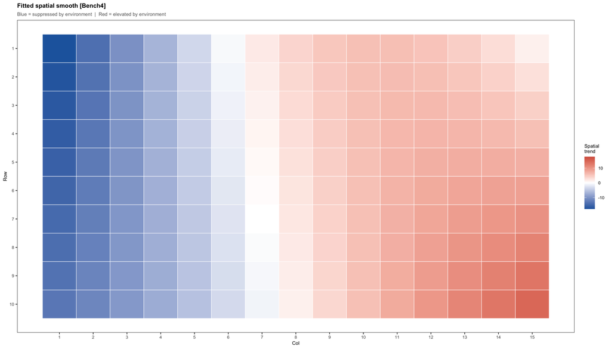

### Inspect the spatial smooth heatmap

After the 6-panel diagnostic, `run_spatial_gamm()` automatically prints a discrete smooth heatmap on the actual plot grid. You can also call `plot_smooth_heatmap()` directly on any fitted model:

```r
# Example: plot the spatial smooth for one bench directly
bench_data_b1 <- sim1$data[sim1$data$Bench == "Bench1", ]
k_dims_b1     <- auto_k_dims(bench_data_b1, "Row", "Col")
model_b1      <- fit_gamm_spatial(bench_data_b1, "BNI", "Genotype", "Row", "Col", k_dims_b1)
plot_smooth_heatmap(model_b1, bench_data_b1, "Row", "Col", bench_label = "Bench1")
```

The smooth heatmap from the GAMM run appears inline above (printed by `run_spatial_gamm()` automatically). The column gradient should be visible as a shift from blue (left columns, suppressed) to red (right columns, elevated).

### Examine BLUPs

Collect per-bench BLUPs and compute a cross-bench mean for each genotype.

```r
blup_list_ex1 <- lapply(results_ex1, function(x) x$dfrP)
blups_ex1     <- do.call(rbind, blup_list_ex1)

# Cross-bench mean BLUP (unweighted)
mean_blups_ex1 <- blups_ex1 %>%
  group_by(Genotype) %>%
  summarise(BNI_BLUP_mean = mean(BNI, na.rm = TRUE), .groups = "drop")

cat("Number of genotypes with BLUPs:", nrow(mean_blups_ex1), "\n")
```

```
## Number of genotypes with BLUPs: 150
```

```r
summary(mean_blups_ex1$BNI_BLUP_mean)
```

```
##    Min. 1st Qu.  Median    Mean 3rd Qu.    Max.
##   58.53   67.87   70.35   70.27   72.59   81.24
```

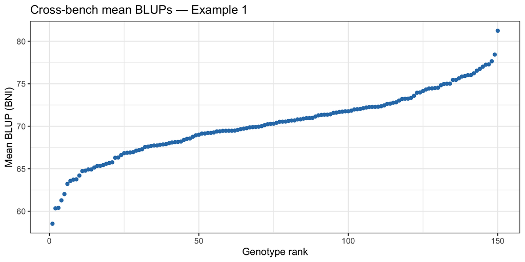

```r
mean_blups_ex1_ord <- mean_blups_ex1[order(mean_blups_ex1$BNI_BLUP_mean), ]
mean_blups_ex1_ord$rank <- seq_len(nrow(mean_blups_ex1_ord))

ggplot(mean_blups_ex1_ord, aes(x = rank, y = BNI_BLUP_mean)) +
  geom_point(size = 1.5, colour = "#2c7bb6") +
  labs(title = "Cross-bench mean BLUPs — Example 1",
       x = "Genotype rank", y = "Mean BLUP (BNI)") +
  theme_bw()
```

### Compare BLUPs to true effects

The `BNI_SpatialTrend` column in the fitted data records the exact spatial adjustment applied to each plot. Visualising this confirms the model captured the column gradient:

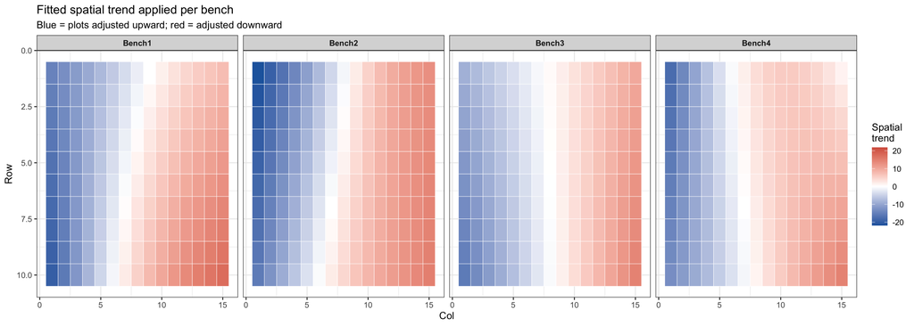

```r
library(viridis)

# Plot SpatialTrend for all benches in a shared colour scale
trend_lim <- max(abs(fitted_ex1$BNI_SpatialTrend), na.rm = TRUE)

ggplot(fitted_ex1, aes(x = col, y = row, fill = BNI_SpatialTrend)) +
  geom_tile(colour = "white", linewidth = 0.2) +
  scale_fill_gradientn(
    colours = c("#2166ac", "white", "#d6604d"),
    limits  = c(-trend_lim, trend_lim),
    name    = "Spatial\ntrend"
  ) +
  scale_y_reverse() +
  facet_wrap(~ Bench, nrow = 1) +
  labs(title = "Fitted spatial trend applied per bench",
       subtitle = "Blue = plots adjusted upward; red = adjusted downward",
       x = "Col", y = "Row") +
  theme_bw() +
  theme(strip.text = element_text(face = "bold"))
```

We can quantify correction performance by correlating the estimated BLUPs against the known true genotype values that were used to generate the data. We also compute the raw-mean correlation as a baseline (what you would get without any correction).

```r
# Raw means (per-genotype average of observed values across benches)
raw_means_ex1 <- sim1$data %>%
  group_by(Genotype) %>%
  summarise(raw_mean = mean(BNI, na.rm = TRUE), .groups = "drop")

# Corrected means (per-genotype average of spatially corrected values)
corrected_means_ex1 <- fitted_ex1 %>%
  group_by(Genotype) %>%
  summarise(corrected_mean = mean(BNI_Corrected, na.rm = TRUE), .groups = "drop")

# Combine with true effects
perf_ex1 <- sim1$true_effects %>%
  inner_join(raw_means_ex1,      by = "Genotype") %>%
  inner_join(corrected_means_ex1, by = "Genotype") %>%
  inner_join(mean_blups_ex1,     by = "Genotype")

cor_raw       <- cor(perf_ex1$raw_mean,       perf_ex1$True_BNI, use = "complete.obs")
cor_corrected <- cor(perf_ex1$corrected_mean, perf_ex1$True_BNI, use = "complete.obs")
cor_blup      <- cor(perf_ex1$BNI_BLUP_mean,  perf_ex1$True_BNI, use = "complete.obs")

cat(sprintf("Pearson r — raw means vs true:       %.3f\n", cor_raw))
```

```
## Pearson r — raw means vs true:       0.944
```

```r
cat(sprintf("Pearson r — corrected means vs true: %.3f\n", cor_corrected))
```

```
## Pearson r — corrected means vs true: 0.979
```

```r
cat(sprintf("Pearson r — BLUPs vs true:           %.3f\n", cor_blup))
```

```
## Pearson r — BLUPs vs true:           0.979
```

The improvement in correlation from raw means to BLUPs quantifies how much of the spatial confounding has been removed. With a peak spatial effect of ~25 BNI units against a genotype SD of 12, this is a genuinely challenging correction.

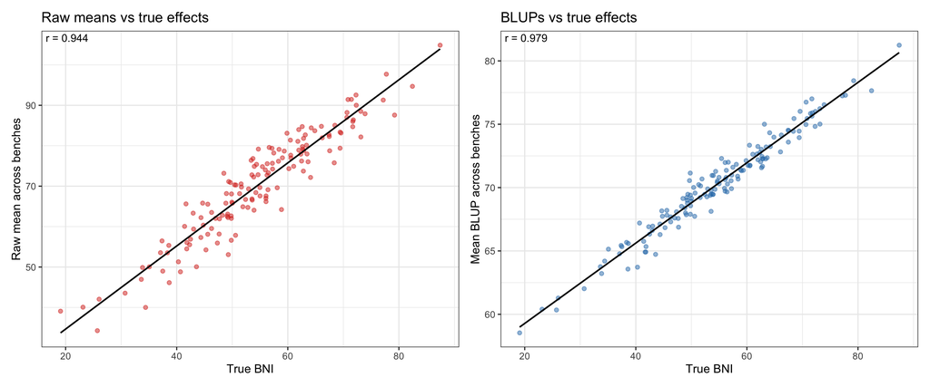

```r
p_raw <- ggplot(perf_ex1, aes(x = True_BNI, y = raw_mean)) +
  geom_point(alpha = 0.5, size = 1.5, colour = "#d7301f") +
  geom_smooth(method = "lm", se = FALSE, colour = "black", linewidth = 0.7) +
  annotate("text", x = -Inf, y = Inf, hjust = -0.1, vjust = 1.4, size = 3.5,
           label = sprintf("r = %.3f", cor_raw)) +
  labs(title = "Raw means vs true effects",
       x = "True BNI", y = "Raw mean across benches") +
  theme_bw()

p_blup <- ggplot(perf_ex1, aes(x = True_BNI, y = BNI_BLUP_mean)) +
  geom_point(alpha = 0.5, size = 1.5, colour = "#2c7bb6") +
  geom_smooth(method = "lm", se = FALSE, colour = "black", linewidth = 0.7) +
  annotate("text", x = -Inf, y = Inf, hjust = -0.1, vjust = 1.4, size = 3.5,
           label = sprintf("r = %.3f", cor_blup)) +
  labs(title = "BLUPs vs true effects",
       x = "True BNI", y = "Mean BLUP across benches") +
  theme_bw()

p_raw + p_blup
```

A well-fitting correction should move the scatter plot from the left panel (where points fan out due to spatial confounding) to the right panel (where points cluster tightly around the diagonal).

### Contrast: per-bench vs pooled for a uniform pattern

For a uniform spatial pattern the per-bench and pooled models should perform equivalently — they are fitting the same surface, just parameterised differently. We verify this here. Example 2 will show what happens when the patterns are **not** uniform.

```r
res_pooled_ex1 <- run_spatial_gamm_pooled(
  dfr            = sim1$data,
  pheno          = "BNI",
  gt             = "Genotype",
  rn             = "Row",
  cn             = "Col",
  bench_col      = "Bench",
  outlier_method = "IQR",
  outlier_k      = 3
)
```

```
##
## --- Pooled model | Trait: BNI | Benches: Bench1, Bench2, Bench3, Bench4 ---
##   k_dims: 5 x 7
##   Fitting initial pooled GAMM...
##   Detecting outliers (method = IQR , k = 3 )...
##   Outliers detected: 0
##   No outliers found.
## [REPORT] Pooled | Trait: BNI
## [REPORT] Method: IQR | k: 3 | Outliers: 0
## [REPORT] ---
##   Fitting final pooled GAMM on cleaned data...
##   Generating pooled diagnostic plots...
##   WARNING: Smooth heatmap failed: replacement has 600 rows, data has 150
```

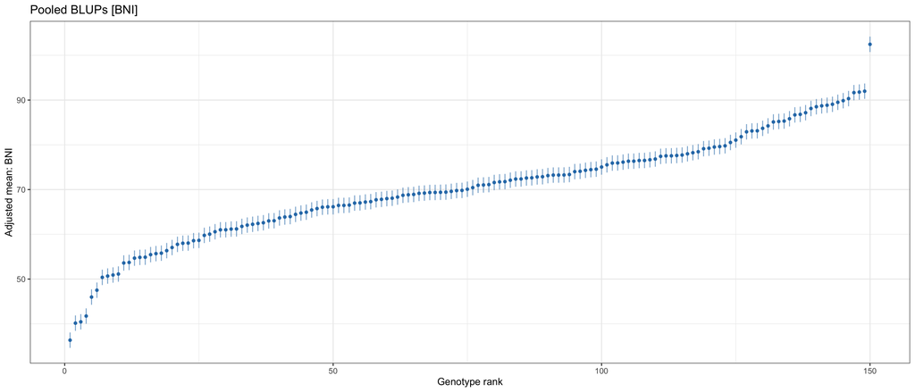

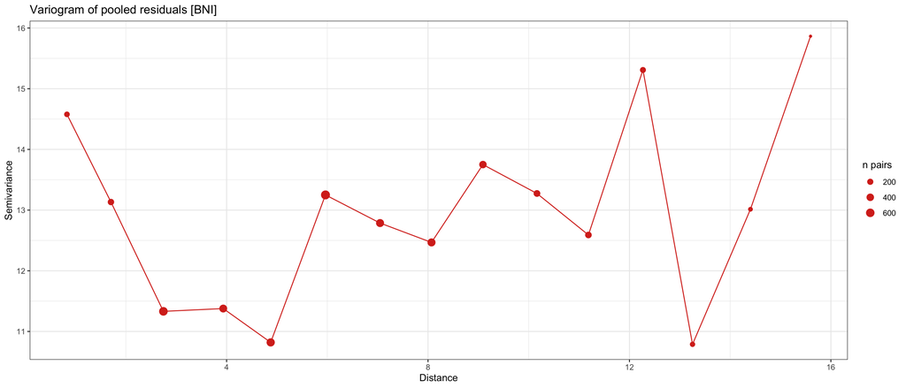

```r
blups_pooled_ex1 <- res_pooled_ex1$dfrP

perf_pooled_ex1 <- sim1$true_effects %>%
  inner_join(blups_pooled_ex1[, c("Genotype", "BNI")], by = "Genotype") %>%
  rename(BNI_BLUP_pooled = BNI)

cor_pooled_ex1 <- cor(perf_pooled_ex1$BNI_BLUP_pooled,
                       perf_pooled_ex1$True_BNI, use = "complete.obs")

cat(sprintf("BLUP r — per-bench (separate smoothers): %.3f\n", cor_blup))
```

```
## BLUP r — per-bench (separate smoothers): 0.979
```

```r
cat(sprintf("BLUP r — pooled   (shared smoother):    %.3f\n", cor_pooled_ex1))
```

```
## BLUP r — pooled   (shared smoother):    0.984
```

```r
cat("\nFor a uniform gradient the two approaches are near-equivalent.\n")
```

```
##
## For a uniform gradient the two approaches are near-equivalent.
```

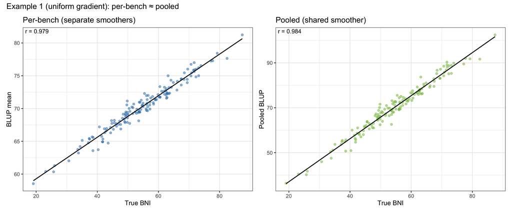

```r
p_sep1 <- ggplot(perf_ex1, aes(x = True_BNI, y = BNI_BLUP_mean)) +
  geom_point(alpha = 0.5, size = 1.5, colour = "#2c7bb6") +
  geom_smooth(method = "lm", se = FALSE, colour = "black", linewidth = 0.7) +
  annotate("text", x = -Inf, y = Inf, hjust = -0.1, vjust = 1.4, size = 3.5,
           label = sprintf("r = %.3f", cor_blup)) +
  labs(title = "Per-bench (separate smoothers)", x = "True BNI", y = "BLUP mean") +
  theme_bw()

p_pool1 <- ggplot(perf_pooled_ex1, aes(x = True_BNI, y = BNI_BLUP_pooled)) +
  geom_point(alpha = 0.5, size = 1.5, colour = "#7fbc41") +
  geom_smooth(method = "lm", se = FALSE, colour = "black", linewidth = 0.7) +
  annotate("text", x = -Inf, y = Inf, hjust = -0.1, vjust = 1.4, size = 3.5,
           label = sprintf("r = %.3f", cor_pooled_ex1)) +
  labs(title = "Pooled (shared smoother)", x = "True BNI", y = "Pooled BLUP") +
  theme_bw()

p_sep1 + p_pool1 +
  plot_annotation(title = "Example 1 (uniform gradient): per-bench ≈ pooled")
```

## Phenotype outputs for downstream analysis (GWAS)

### BLUP, BLUE and de-regressed BLUP — what is the difference?

All three values are in the `dfrP` output table. They serve different downstream purposes:

| Value | Column | Calculation | Use |
| --- | --- | --- | --- |
| **BLUP** | `BNI` | grand mean + shrunken genotype RE | Ranking, selection, genetic parameters |
| **BLUE** | `BNI_BLUE` | mean spatially corrected observation | GWAS with kinship matrix; unbiased, no shrinkage |
| **de-regressed BLUP** | `BNI_deBLUP` | grand mean + ranef / reliability | GWAS tools expecting de-regressed values + weights |

The **reliability** column (`BNI_Reliability`) is the shrinkage factor:
$$\text{reliability} = \frac{\sigma_g^2}{\sigma_g^2
+ \sigma_e^2 / n_{\text{rep}}}$$

For a GWAS with a kinship matrix (EMMAX, GCTA, BGLR):
$$\hat{g}_k^{\text{BLUE}} =
\bar{y}_k^{\text{corrected}} \quad \text{(mean spatially corrected value
across benches)}$$

For de-regressed BLUPs (Garrick et al. 2009, used in animal breeding GWAS):
$$\hat{g}_k^{\text{deBLUP}} = \mu +
\frac{\hat{u}_k}{\text{reliability}_k}$$

where $\hat{u}_k$ is the raw (unscaled) random effect deviation. De-regressed BLUPs are weighted in GWAS by $w_k = \text{reliability}_k / (1 - \text{reliability}_k)$.

### When to use which

| GWAS workflow | Recommended output | Do NOT use |
| --- | --- | --- |
| Single-step (kinship model on raw data) | BNI_Corrected from dfrF (plot-level) | — |
| Two-step: kinship model on pre-adjusted phenotype | BNI_BLUE (cross-bench mean, no shrinkage) | BNI (BLUP — shrinkage attenuates marker effects) |
| Two-step: no kinship (simple regression per marker) | BNI_BLUE (unbiased, but population structure uncorrected) | BNI (BLUP — double-shrinkage) |
| Selection / ranking | BNI (BLUP — shrunken, best ranking accuracy) | BNI_BLUE (noisier than BLUP for ranking) |
| Heritability / genetic parameter estimation | BNI (BLUP reliabilities inform heritability) | — |

### Performance comparison: BLUP vs BLUE vs de-regressed BLUP

```r
# Collect cross-bench means for all three output types from Example 1
blup_list_ex1 <- lapply(results_ex1, function(x) x$dfrP)
blups_all_ex1 <- do.call(rbind, blup_list_ex1)

gwas_means <- blups_all_ex1 %>%
  group_by(Genotype) %>%
  summarise(
    BLUP   = mean(BNI,          na.rm = TRUE),
    BLUE   = mean(BNI_BLUE,     na.rm = TRUE),
    deBLUP = mean(BNI_deBLUP,  na.rm = TRUE),
    .groups = "drop"
  )

gwas_perf <- sim1$true_effects %>%
  inner_join(gwas_means, by = "Genotype")

r_blup   <- round(cor(gwas_perf$BLUP,   gwas_perf$True_BNI, use = "complete.obs"), 3)
r_blue   <- round(cor(gwas_perf$BLUE,   gwas_perf$True_BNI, use = "complete.obs"), 3)
r_deblup <- round(cor(gwas_perf$deBLUP, gwas_perf$True_BNI, use = "complete.obs"), 3)

cat(sprintf("Pearson r vs true effect — BLUP:   %.3f\n", r_blup))
```

```
## Pearson r vs true effect — BLUP:   0.979
```

```r
cat(sprintf("Pearson r vs true effect — BLUE:   %.3f\n", r_blue))
```

```
## Pearson r vs true effect — BLUE:   0.979
```

```r
cat(sprintf("Pearson r vs true effect — deBLUP: %.3f\n", r_deblup))
```

```
## Pearson r vs true effect — deBLUP: 0.979
```

[figure not shown]

```r
# Show the three options side by side
gwas_long <- gwas_perf %>%
  tidyr::pivot_longer(c(BLUP, BLUE, deBLUP),
                      names_to = "Type", values_to = "Value") %>%
  mutate(Type = factor(Type, levels = c("BLUP", "BLUE", "deBLUP")))

r_ann_gwas <- data.frame(
  Type  = factor(c("BLUP", "BLUE", "deBLUP"), levels = c("BLUP", "BLUE", "deBLUP")),
  label = paste0("r = ", c(r_blup, r_blue, r_deblup))
)

ggplot(gwas_long, aes(x = True_BNI, y = Value)) +
  geom_point(alpha = 0.4, size = 1.5, colour = "#2c7bb6") +
  geom_smooth(method = "lm", se = FALSE, colour = "#d7301f", linewidth = 0.8) +
  geom_abline(slope = 1, intercept = 0, linetype = "dashed",
              colour = "grey50", linewidth = 0.5) +
  geom_text(data = r_ann_gwas, aes(x = -Inf, y = Inf, label = label),
            hjust = -0.1, vjust = 1.5, size = 3.5, inherit.aes = FALSE) +
  facet_wrap(~ Type, nrow = 1) +
  labs(
    title    = "BLUP vs BLUE vs de-regressed BLUP — Example 1 (uniform gradient)",
    subtitle = paste0("All three recover the true effect well (r ≥ ", min(r_blup, r_blue, r_deblup),
                      "). BLUPs are shrunk toward the mean; BLUEs and deBLUPs lie on the y=x line."),
    x = "True BNI", y = "Estimated value"
  ) +
  theme_bw() +
  theme(strip.text = element_text(face = "bold", size = 10))
```

For GWAS, use the **cross-bench mean BLUE** (`BNI_BLUE` averaged across benches, computed above as `gwas_means$BLUE`). If your GWAS software requires reliability weights (e.g. `wt_GWAS = reliability / (1 - reliability)`), use `BNI_deBLUP` with those weights.

## Tutorial — Example 2: Heterogeneous spatial patterns

### Scenario

In practice, different benches often have different spatial structures — a bench near a heating vent may show a localised warm patch, while a bench in the open aisle shows a smooth end-to-end gradient.

In this example we simulate a four-bench trial where:

- **Bench_Grad1 and Bench_Grad2** have a column gradient (same as Example 1)
- **Bench_Patch1 and Bench_Patch2** have a central Gaussian hot-spot

Because `simulate_field_trial()` is deterministic (given the same seed, grid dimensions, and genotype parameters), calling it twice with the same `seed`, `n_bench`, `n_rows`, and `n_cols` but different `spatial_type` produces:

- **Identical true genotype effects** (both calls draw `geno_true` from the same RNG state)
- **Identical within-bench plot assignments** and noise vectors
- **Different spatial surfaces** only

This means Example 2 uses the exact same 150 genotypes with the same underlying values as Example 1 — only the environmental context differs in benches 3 and 4.

### The modelling question

Example 1 showed that per-bench and pooled models give near-identical results when all benches share the same spatial structure. In that situation the pooled model is slightly more parsimonious.

This example tests the **heterogeneous case**. We will fit both models and compare:

- **Per-bench model** — separate `te(Row, Col)` for each bench, estimated independently. Adapts freely to any pattern.
- **Pooled model** — one shared `te(Row, Col)` across all benches. Only valid if all benches have the same spatial structure.

The per-bench model should excel here; the pooled model should underperform because it must fit a single compromise surface over four genuinely different spatial patterns.

### Simulate mixed-pattern data

```r
# Benches 1-2: column gradient
sim_grad <- simulate_field_trial(
  n_bench = 2, n_rows = 10, n_cols = 15,
  mean_pheno = 55, sd_geno = 12,
  spatial_type = 3, spatial_intensity = 25,
  sd_error = 4, pheno_name = "BNI",
  save_csv = FALSE, seed = 42
)

# Benches 3-4: central Gaussian patch (same seed → same genotype effects)
sim_patch <- simulate_field_trial(
  n_bench = 2, n_rows = 10, n_cols = 15,
  mean_pheno = 55, sd_geno = 12,
  spatial_type = 5, spatial_intensity = 25,
  sd_error = 4, pheno_name = "BNI",
  save_csv = FALSE, seed = 42
)

# Rename bench identifiers so they are unique after combining
sim_grad$data$Bench  <- gsub("Bench", "Bench_Grad",  sim_grad$data$Bench)
sim_patch$data$Bench <- gsub("Bench", "Bench_Patch", sim_patch$data$Bench)

sim2_data    <- rbind(sim_grad$data, sim_patch$data)
true_efx2    <- sim_grad$true_effects   # identical to sim_patch$true_effects

cat("Total plots:", nrow(sim2_data), "\n")
```

```
## Total plots: 600
```

```r
cat("Bench IDs: ", paste(unique(sim2_data$Bench), collapse = ", "), "\n")
```

```
## Bench IDs:  Bench_Grad1, Bench_Grad2, Bench_Patch1, Bench_Patch2
```

### Visualise raw data — different patterns clearly visible

```r
plot_all_bench_heatmaps(
  dfr          = sim2_data,
  pheno        = "BNI",
  bench_col    = "Bench",
  shared_scale = TRUE,
  ncol_panels  = 2,
  panel_width  = 7,
  panel_height = 4,
  output_png   = "data/ex2_raw_heatmap.png"
)
```

```
## Heatmap saved to: data/ex2_raw_heatmap.png
```

### Run the spatial GAMM — same pipeline, heterogeneous data

The call to `run_spatial_gamm()` is identical to Example 1. No special configuration is needed for the mixed-pattern benches.

```r
benches_ex2 <- unique(sim2_data$Bench)
results_ex2 <- list()
fitted_ex2  <- NULL

for (b in benches_ex2) {

  bench_data <- sim2_data[sim2_data$Bench == b, ]

  res <- run_spatial_gamm(
    mydfr          = bench_data,
    pheno          = "BNI",
    gt             = "Genotype",
    rn             = "Row",
    cn             = "Col",
    bench_label    = b,
    pmain          = paste("Ex2", b),
    outlier_method = "IQR",
    outlier_k      = 3
  )

  if (!is.null(res)) {
    results_ex2[[b]] <- res
    fitted_ex2 <- if (is.null(fitted_ex2)) res$dfrF else rbind(fitted_ex2, res$dfrF)
  }
}
```

```
##
## --- Bench: Bench_Grad1 | Trait: BNI ---
##   k_dims: 5 x 7
##   Fitting initial GAMM...
##   Detecting outliers (method = IQR , k = 3 )...
##   Outliers detected: 0
##   No outliers found.
## [REPORT] Bench: Bench_Grad1 | Trait: BNI
## [REPORT] Method: IQR | k: 3 | Outliers: 0
## [REPORT] ---
##   Fitting final GAMM on cleaned data...
##   Generating diagnostic plots...
```

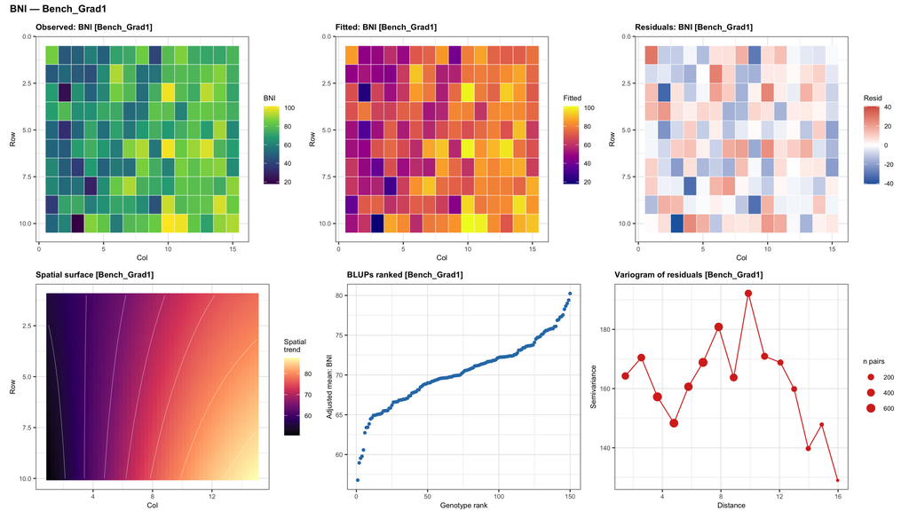

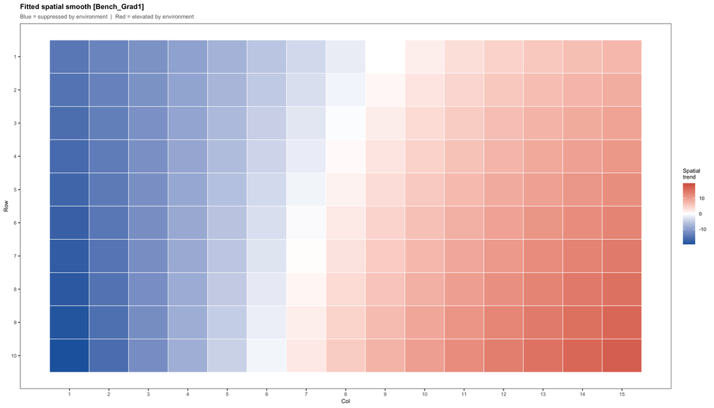

```
##
## --- Bench: Bench_Grad2 | Trait: BNI ---
##   k_dims: 5 x 7
##   Fitting initial GAMM...
##   Detecting outliers (method = IQR , k = 3 )...
##   Outliers detected: 0
##   No outliers found.
## [REPORT] Bench: Bench_Grad2 | Trait: BNI
## [REPORT] Method: IQR | k: 3 | Outliers: 0
## [REPORT] ---
##   Fitting final GAMM on cleaned data...
##   Generating diagnostic plots...
```

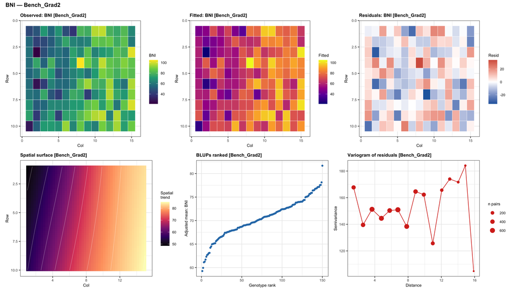

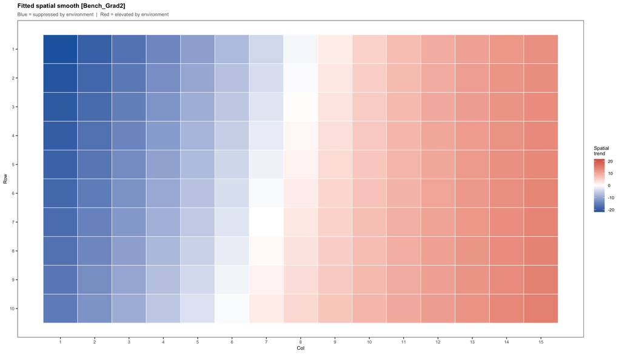

```
##
## --- Bench: Bench_Patch1 | Trait: BNI ---
##   k_dims: 5 x 7
##   Fitting initial GAMM...
##   Detecting outliers (method = IQR , k = 3 )...
##   Outliers detected: 0
##   No outliers found.
## [REPORT] Bench: Bench_Patch1 | Trait: BNI
## [REPORT] Method: IQR | k: 3 | Outliers: 0
## [REPORT] ---
##   Fitting final GAMM on cleaned data...
##   Generating diagnostic plots...
```

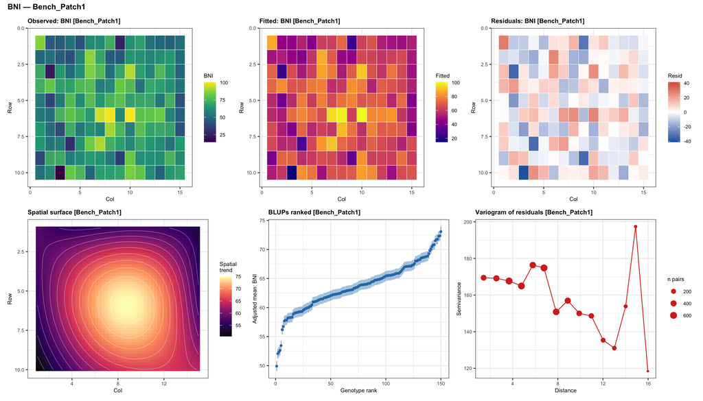

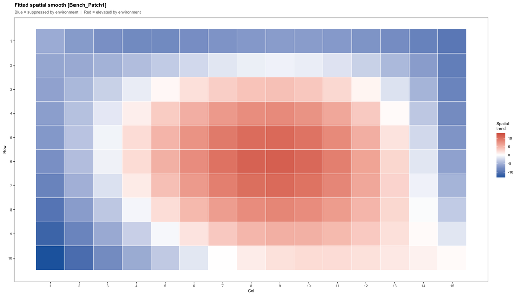

```
##
## --- Bench: Bench_Patch2 | Trait: BNI ---
##   k_dims: 5 x 7
##   Fitting initial GAMM...
##   Detecting outliers (method = IQR , k = 3 )...
##   Outliers detected: 0
##   No outliers found.
## [REPORT] Bench: Bench_Patch2 | Trait: BNI
## [REPORT] Method: IQR | k: 3 | Outliers: 0
## [REPORT] ---
##   Fitting final GAMM on cleaned data...
##   Generating diagnostic plots...
```

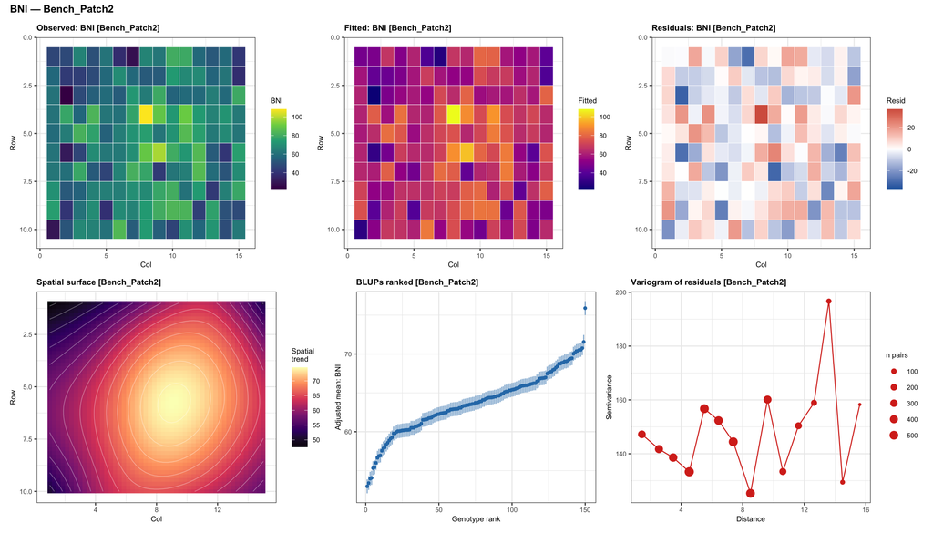

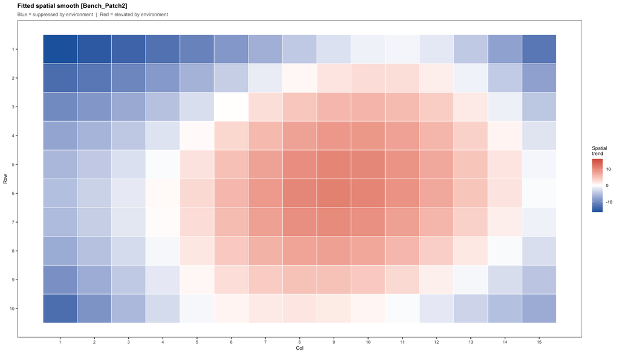

### What the diagnostic plots reveal

Examine **Panel 4 (Spatial surface)** across the four benches:

- **Bench_Grad1 and Bench_Grad2:** the surface should show a monotone ramp from left (low) to right (high), confirming the model captured the column gradient
- **Bench_Patch1 and Bench_Patch2:** the surface should show a central elevated region fading toward the edges — the model adapts its shape to match the Gaussian hot-spot without any user input

**Panel 3 (Residuals)** should look spatially unstructured in all four cases, confirming that the spatial trend has been successfully removed regardless of its shape.

**Panel 6 (Variogram)** should flatten quickly for all benches. Any sustained upward slope would suggest residual spatial autocorrelation — a sign that the smooth complexity (`k_dims`) may need to be increased.

### Compare BLUPs to true effects

```r
blup_list_ex2 <- lapply(results_ex2, function(x) x$dfrP)
blups_ex2     <- do.call(rbind, blup_list_ex2)

mean_blups_ex2 <- blups_ex2 %>%
  group_by(Genotype) %>%
  summarise(BNI_BLUP_mean = mean(BNI, na.rm = TRUE), .groups = "drop")

raw_means_ex2 <- sim2_data %>%
  group_by(Genotype) %>%
  summarise(raw_mean = mean(BNI, na.rm = TRUE), .groups = "drop")

corrected_means_ex2 <- fitted_ex2 %>%
  group_by(Genotype) %>%
  summarise(corrected_mean = mean(BNI_Corrected, na.rm = TRUE), .groups = "drop")

perf_ex2 <- true_efx2 %>%
  inner_join(raw_means_ex2,       by = "Genotype") %>%
  inner_join(corrected_means_ex2, by = "Genotype") %>%
  inner_join(mean_blups_ex2,      by = "Genotype")

cor_raw_ex2  <- cor(perf_ex2$raw_mean,       perf_ex2$True_BNI, use = "complete.obs")
cor_corr_ex2 <- cor(perf_ex2$corrected_mean, perf_ex2$True_BNI, use = "complete.obs")
cor_blup_ex2 <- cor(perf_ex2$BNI_BLUP_mean,  perf_ex2$True_BNI, use = "complete.obs")

cat(sprintf("Pearson r — raw means vs true:       %.3f\n", cor_raw_ex2))
```

```
## Pearson r — raw means vs true:       0.932
```

```r
cat(sprintf("Pearson r — corrected means vs true: %.3f\n", cor_corr_ex2))
```

```
## Pearson r — corrected means vs true: 0.958
```

```r
cat(sprintf("Pearson r — BLUPs vs true:           %.3f\n", cor_blup_ex2))
```

```
## Pearson r — BLUPs vs true:           0.958
```

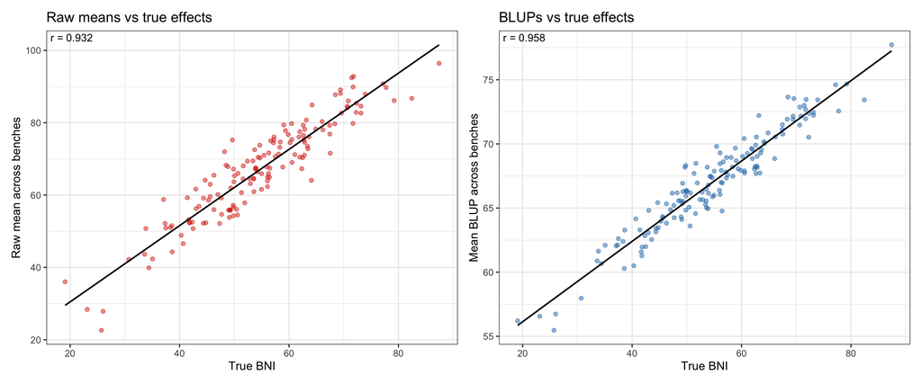

```r
p_raw2 <- ggplot(perf_ex2, aes(x = True_BNI, y = raw_mean)) +
  geom_point(alpha = 0.5, size = 1.5, colour = "#d7301f") +
  geom_smooth(method = "lm", se = FALSE, colour = "black", linewidth = 0.7) +
  annotate("text", x = -Inf, y = Inf, hjust = -0.1, vjust = 1.4, size = 3.5,
           label = sprintf("r = %.3f", cor_raw_ex2)) +
  labs(title = "Raw means vs true effects",
       x = "True BNI", y = "Raw mean across benches") +
  theme_bw()

p_blup2 <- ggplot(perf_ex2, aes(x = True_BNI, y = BNI_BLUP_mean)) +
  geom_point(alpha = 0.5, size = 1.5, colour = "#2c7bb6") +
  geom_smooth(method = "lm", se = FALSE, colour = "black", linewidth = 0.7) +
  annotate("text", x = -Inf, y = Inf, hjust = -0.1, vjust = 1.4, size = 3.5,
           label = sprintf("r = %.3f", cor_blup_ex2)) +
  labs(title = "BLUPs vs true effects",
       x = "True BNI", y = "Mean BLUP across benches") +
  theme_bw()

p_raw2 + p_blup2
```

### Spatial trend heatmaps — different patterns per bench

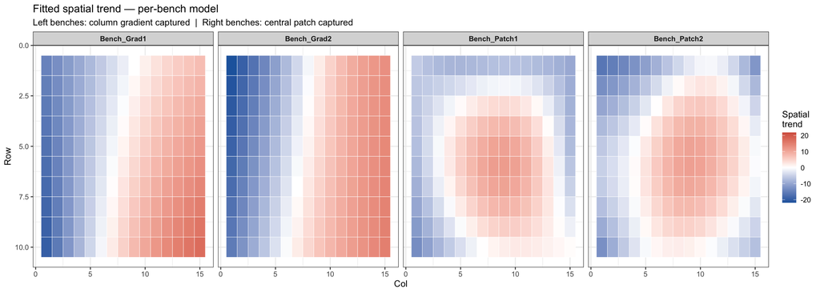

```r
trend_lim2 <- max(abs(fitted_ex2$BNI_SpatialTrend), na.rm = TRUE)

ggplot(fitted_ex2, aes(x = col, y = row, fill = BNI_SpatialTrend)) +
  geom_tile(colour = "white", linewidth = 0.2) +
  scale_fill_gradientn(
    colours = c("#2166ac", "white", "#d6604d"),
    limits  = c(-trend_lim2, trend_lim2),
    name    = "Spatial\ntrend"
  ) +
  scale_y_reverse() +
  facet_wrap(~ Bench, nrow = 1) +
  labs(title = "Fitted spatial trend — per-bench model",
       subtitle = "Left benches: column gradient captured  |  Right benches: central patch captured",
       x = "Col", y = "Row") +
  theme_bw() +
  theme(strip.text = element_text(face = "bold"))
```

The heatmaps confirm that the per-bench model has correctly identified different spatial structures: a monotone left-to-right ramp for the gradient benches, and a central hot-spot for the patch benches.